# dimensionreduction.cosmxdata

#**Code to run steps from the previous chapters to generate the SpatialExperiment object required for this chapter:**

library(SpatialExperiment)

library(STexampleData)

library(scater)

library(scran)

library(ggspavis)

spe <- readRDS(“C:/Users/sanaz/OneDrive/Documents/cosmx_lung_5_rep1_SPE.RDS”)

qc_Width = colData(spe)$Width > 200

colData(spe)$qc_Width = qc_Width

qc_Height = colData(spe)$Height > 200

colData(spe)$qc_Height = qc_Height

qc_Mean.PanCK = colData(spe)$Mean.PanCK > 60000

colData(spe)$qc_Mean.PanCK = qc_Mean.PanCK

qc_Mean.DAPI = colData(spe)$Mean.DAPI > 30000

colData(spe)$qc_Mean.DAPI = qc_Mean.DAPI

apply(cbind(qc_Width, qc_Height, qc_Mean.PanCK, qc_Mean.DAPI), 2, sum)

discard = qc_Width | qc_Height | qc_Mean.PanCK | qc_Mean.DAPI

table(discard)

colData(spe)$discard = discard

spe = spe[, !colData(spe)$discard]

spe = spe[, colSums(counts(spe)) > 0]

spe = computeLibraryFactors(spe)

spe = logNormCounts(spe)

dec = modelGeneVar(spe)

top_hvgs = getTopHVGs(dec, prop = 0.1)

#**Compute PCA:**

set.seed(123)

spe = runPCA(spe, subset_row = top_hvgs)

reducedDimNames(spe)

dim(reducedDim(spe, “PCA”))

#‘’PCA’’

#99772 50

#Compute UMAP on top 50 PCs:

set.seed(123)

spe = runUMAP(spe, dimred = “PCA”)

reducedDimNames(spe)

dim(reducedDim(spe, “UMAP”))

#‘’PCA’’ ’’UMAP”

#99772 2

#Update column names for easier plotting:

colnames(reducedDim(spe, “UMAP”)) = paste0(“UMAP”, 1:2)

#**Plot top 2 PCA dimensions:**

plotDimRed(spe, type = “PCA”)

[figure not shown]

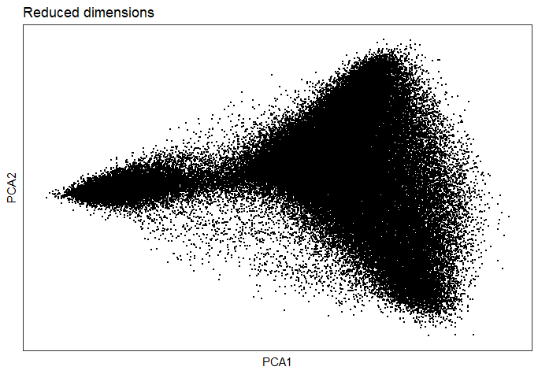

[figure not shown]

**#Plot top 2 UMAP dimensions:**

plotDimRed(spe, type = “UMAP”)

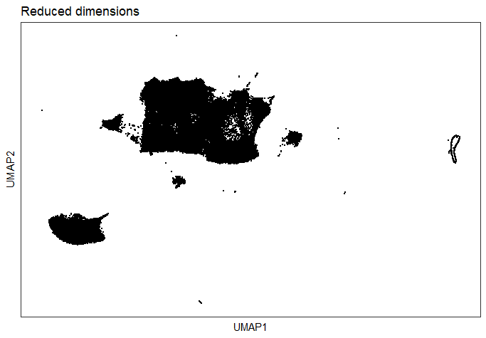